# Tuesday homework - titanic decision tree

```r
library(rpart)
library(rpart.plot)
library(tidyverse)
library(janitor)

titanic_set <- read_csv('data/titanic_decision_tree_data.csv') %>%
  clean_names()
shuffle_index <- sample(1:nrow(titanic_set))

# shuffle the data so class order isn't in order - need this for training/testing split later on
titanic_set <- titanic_set[shuffle_index, ]
```

Data dictionary from homework file:

- sex: Biological Sex, male or female
- age_status: adult or child (child defined as under 16)
- class : Ticket class, 1 = 1st (Upper class), 2 = 2nd (Middle Class), 3 = 3rd (Lower Class)
- port_embarkation: C = Cherbourg, Q = Queenstown, S = Southampton
- sibsp : number of siblings / spouses aboard the Titanic
- parch: number of parents / children aboard the Titanic. Some children travelled only with a nanny, therefore parch=0 for them.
- survived_flag : did they survive, 0 = No, 1 = Yes

# 1. Cleaning

```r
titanic_subset <- titanic_set %>% #1309
  filter(!is.na(survived)) %>% #891 rows
  mutate(age_status = case_when(
    age <= 16 ~ "child",
    age > 16 ~ "adult",
    .default = NA_character_), .after = age) %>%
  mutate(across(.cols = c(sex, survived, pclass, embarked, age_status),
                .fns = ~ factor(.x))) %>%
  mutate(pclass = factor(pclass, levels = c("1", "2", "3")),
         survived = factor(survived, levels = c("1", "0"), labels = c("yes","no"))) %>%
  select(-c(x1, passenger_id, name, ticket, fare, cabin)) %>%
  drop_na() # 712 rows
```

Dropped 179 rows with NAs:

- 177 NAs in age and age status
- 2 diff NAs in embarked

```r
# check factor levels
levels(titanic_subset$survived) # survived = TRUE (1) is first
```

```
[1] "yes" "no"
```

```r
levels(titanic_subset$pclass)
```

```
[1] "1" "2" "3"
```

```r
dim(titanic_subset)
```

```
[1] 712   8
```

712 observations 8 vars - 7 predictors (incl. both age + age_status) of outcome (survived)

# 2. Explore predictors

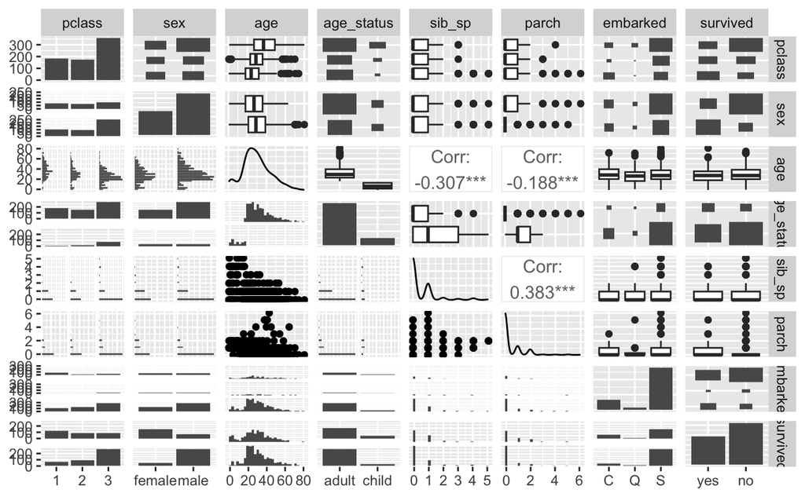

```r
titanic_subset %>%
  GGally::ggpairs(progress = F)
```

Promising predictor vars (with approximate strength of correlation):

- pclass - looks like proportion(survived) changes with class
- sex - definite pattern in survived v not by gender
- age_status - different changes in box size here - top row survived slightly more than not; bottom row survived less than not survived
- embarked - looks like a pattern in survived v embarkation location - some proportions(survived) lower than others

Notice also that age, parch, sib_sp are correlated - because age status child –> has siblings and parents (or not), maybe once age_status used the other variables may not contribute much

```r
alias(survived ~ ., titanic_subset)
```

```
Model :
survived ~ pclass + sex + age + age_status + sib_sp + parch +
    embarked
```

No aliases in the numeric data

```r
skimr::skim(titanic_subset)
```

```
── Data Summary ────────────────────────
                           Values
Name                       titanic_subset
Number of rows             712
Number of columns          8
_______________________
Column type frequency:
  factor                   5
  numeric                  3
________________________
Group variables            None
```

|  | skim_variable | n_missing | complete_rate | ordered | n_unique | top_counts |
| --- | --- | --- | --- | --- | --- | --- |
| 1 | pclass | 0 | 1 | FALSE | 3 | 3: 355, 1: 184, 2: 173 |
| 2 | sex | 0 | 1 | FALSE | 2 | mal: 453, fem: 259 |
| 3 | age_status | 0 | 1 | FALSE | 2 | adu: 612, chi: 100 |
| 4 | embarked | 0 | 1 | FALSE | 3 | S: 554, C: 130, Q: 28 |
| 5 | survived | 0 | 1 | FALSE | 2 | no: 424, yes: 288 |

|  | skim_variable | n_missing | complete_rate | mean | sd | p0 | p25 | p50 | p75 | p100 | hist |
| --- | --- | --- | --- | --- | --- | --- | --- | --- | --- | --- | --- |
| 1 | age | 0 | 1 | 29.6420927 | 14.4929329 | 0.42 | 20 | 28 | 38 | 80 | ▂▇▅▂▁ |
| 2 | sib_sp | 0 | 1 | 0.5140449 | 0.9306921 | 0.00 | 0 | 0 | 1 | 5 | ▇▁▁▁▁ |
| 3 | parch | 0 | 1 | 0.4325843 | 0.8541814 | 0.00 | 0 | 0 | 1 | 6 | ▇▁▁▁▁ |

# 3. Test-train split

We have 712 observations - use 20% for test

```r
# set up test-train split
test_split <- 0.2
n_data <- nrow(titanic_subset)

test_index <- sample(1:n_data, size = n_data * test_split)

# split data
titanic_test <- slice(titanic_subset, test_index)
titanic_train <- slice(titanic_subset, -test_index)

# check proportion(survived) in whole, test and train
tabyl(titanic_test, survived)
```

```
 survived  n   percent
      yes 57 0.4014085
       no 85 0.5985915
```

```r
tabyl(titanic_train, survived)
```

```
 survived   n   percent
      yes 231 0.4052632
       no 339 0.5947368
```

```r
tabyl(titanic_subset, survived)
```

```
 survived   n   percent
      yes 288 0.4044944
       no 424 0.5955056
```

So the split is fairly balanced. Proceed as is.

```r
dim(titanic_train)
```

```
[1] 570   8
```

```r
dim(titanic_test)
```

```
[1] 142   8
```

Check: 570 obs (80% of 712) in training dataset, 142 (20%) in test.

## homework answers

can stratify not just to balance the outcome % but also to balance the potential key predictors, e.g. class, age, etc - this is important for getting good spec and sens

# 4. Make decision tree model

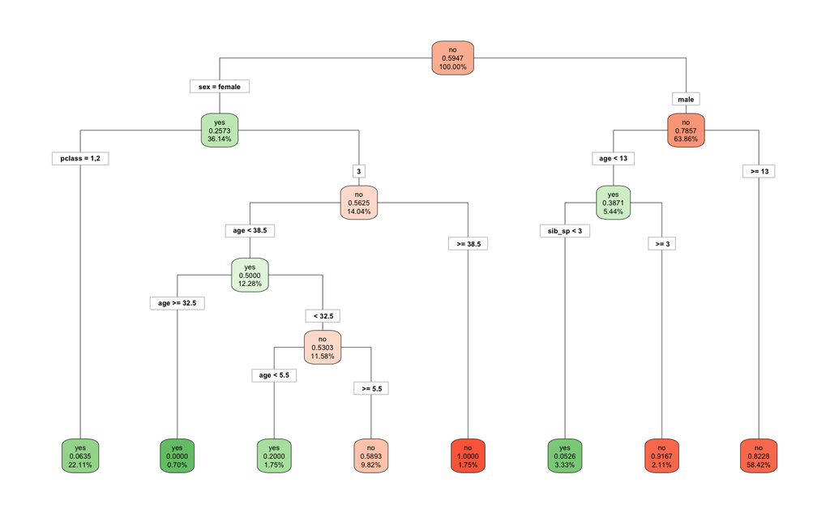

```r
titanic_fit <- rpart(survived ~ .,
                     data = titanic_train,
                     method = "class",
                     control = rpart.control(minsplit = 3))

tree <- rpart.plot(titanic_fit,
           yesno = 1,
           fallen.leaves = TRUE,
           faclen = 6,
           digits = 4,
           type = 4,
           split.border.col = 8,
           box.palette = "GnRd")
```

# 5. Intrepret decision tree model

```r
titanic_fit
```

```
n= 570

node), split, n, loss, yval, (yprob)
      * denotes terminal node

 1) root 570 231 no (0.40526316 0.59473684)
   2) sex=female 206  53 yes (0.74271845 0.25728155)
     4) pclass=1,2 126   8 yes (0.93650794 0.06349206) *
     5) pclass=3 80  35 no (0.43750000 0.56250000)
      10) age< 38.5 70  35 yes (0.50000000 0.50000000)
        20) age>=32.5 4   0 yes (1.00000000 0.00000000) *
        21) age< 32.5 66  31 no (0.46969697 0.53030303)
          42) age< 5.5 10   2 yes (0.80000000 0.20000000) *
          43) age>=5.5 56  23 no (0.41071429 0.58928571) *
      11) age>=38.5 10   0 no (0.00000000 1.00000000) *
   3) sex=male 364  78 no (0.21428571 0.78571429)
     6) age< 13 31  12 yes (0.61290323 0.38709677)
      12) sib_sp< 2.5 19   1 yes (0.94736842 0.05263158) *
      13) sib_sp>=2.5 12   1 no (0.08333333 0.91666667) *
     7) age>=13 333  59 no (0.17717718 0.82282282) *
```

Note the probability decimals are prob(0, “no”) not prob(1, “yes”), so prob(survived) = 1 - decimal

These data suggest that the following passengers were prioritised in the lifeboats:

- women of upper and middle class
- age bands may indicate that lower class mothers (32.5-38.5 years old) with young children (5.5 years or less) were prioritised
- children of either sex, with girls prioritised over boys where families had 4 or more children (boys with 3 or more siblings were much less likely to survive)

# 6. Predict test set & analyse tree performance

[output not shown]

```r
titanic_test_pred %>%
  yardstick::conf_mat(truth = survived, estimate = pred)
```

```
          Truth
Prediction yes no
       yes  35  4
       no   22 81
```

```r
TP <- 35
FN <- 22
TN <- 81
FP <- 4

accuracy <- (TP + TN) / (TP + TN + FP + FN)

TPR_sens <- TP / (TP + FN)

TNR_spec <- TN / (TN + FP)

accuracy
```

```
[1] 0.8169014
```

```r
TPR_sens
```

```
[1] 0.6140351
```

```r
TNR_spec
```

```
[1] 0.9529412
```

Accuracy of predicting survival or not is 81.7% (using data in which 40% passengers survived)

Sensitivity is 61.4% (rate at which model predicts true for all true cases)

Specificity is 95.2% (rate at which model predicts false for all false cases)

So this model is pretty sensitive to non-survival, but is not managing to predict survived for all survived passengers (some predicted as not survived).

Maybe this makes sense for a model that is imbalanced towards non-survival.

# Extension

Create a random forest model

```r
library(ranger)

titanic_classifier <- ranger(survived ~ .,
                             titanic_train,
                             importance = "impurity",
                             num.trees = 500,
                             min.node.size = 3)

titanic_classifier
```

```
Ranger result

Call:
 ranger(survived ~ ., titanic_train, importance = "impurity",      num.trees = 500, min.node.size = 3)

Type:                             Classification
Number of trees:                  500
Sample size:                      570
Number of independent variables:  7
Mtry:                             2
Target node size:                 3
Variable importance mode:         impurity
Splitrule:                        gini
OOB prediction error:             18.95 %
```

```r
importance(titanic_classifier)
```

```
    pclass        sex        age age_status     sib_sp      parch
 31.818472  62.184298  35.349622   5.384320  12.414244   9.879404
  embarked
  6.945784
```

```r
titanic_test_rf_pred <- titanic_test %>%
  mutate(pred = predict(titanic_classifier, data = titanic_test)$predictions)

head(titanic_test_rf_pred, 20)
```

| pclass | sex | age | age_status | sib_sp | parch | embarked | survived | pred |
| --- | --- | --- | --- | --- | --- | --- | --- | --- |
| 3 | male | 19 | adult | 0 | 0 | S | no | no |
| 1 | female | 39 | adult | 1 | 0 | S | yes | yes |
| 3 | male | 36 | adult | 0 | 0 | S | no | no |
| 2 | female | 36 | adult | 1 | 0 | S | yes | yes |
| 1 | female | 19 | adult | 0 | 0 | S | yes | yes |
| 3 | male | 21 | adult | 0 | 0 | S | no | no |
| 3 | female | 18 | adult | 0 | 0 | Q | no | no |
| 3 | female | 21 | adult | 0 | 0 | S | yes | no |
| 3 | male | 24 | adult | 0 | 0 | S | no | no |
| 3 | male | 16 | child | 2 | 0 | S | no | no |

[output cut: 10 more lines]

```r
caret::confusionMatrix(titanic_test_rf_pred$pred, titanic_test_rf_pred$survived)
```

```
Confusion Matrix and Statistics

          Reference
Prediction yes no
       yes  38  3
       no   19 82

               Accuracy : 0.8451
                 95% CI : (0.7749, 0.9003)
    No Information Rate : 0.5986
    P-Value [Acc > NIR] : 1.672e-10

                  Kappa : 0.662

 Mcnemar's Test P-Value : 0.001384

            Sensitivity : 0.6667
            Specificity : 0.9647
         Pos Pred Value : 0.9268
         Neg Pred Value : 0.8119
             Prevalence : 0.4014
         Detection Rate : 0.2676
   Detection Prevalence : 0.2887
      Balanced Accuracy : 0.8157

       'Positive' Class : yes
```

Compare to signle decision tree:

```r
caret::confusionMatrix(titanic_test_pred$pred, titanic_test_pred$survived)
```

```
Confusion Matrix and Statistics

          Reference
Prediction yes no
       yes  35  4
       no   22 81

               Accuracy : 0.8169
                 95% CI : (0.7433, 0.8768)
    No Information Rate : 0.5986
    P-Value [Acc > NIR] : 2.018e-08

                  Kappa : 0.5981

 Mcnemar's Test P-Value : 0.0008561

            Sensitivity : 0.6140
            Specificity : 0.9529
         Pos Pred Value : 0.8974
         Neg Pred Value : 0.7864
             Prevalence : 0.4014
         Detection Rate : 0.2465
   Detection Prevalence : 0.2746
      Balanced Accuracy : 0.7835

       'Positive' Class : yes
```

Kappa is higher in the random forest model, as are accuracy, sensitivity and specificity too.

*Did not tune the hyperparamters, out of time.*

```r
# make function for doing all the yardstick measures
model_stats <- function(df, flag, pred) {

  conf_mat <- df %>%
    yardstick::conf_mat(truth = .data[[flag]], estimate = .data[[pred]])

  # accuracy <- df %>%
  #   yardstick::accuracy(truth = {flag}, estimate = {pred})
  #
  # sensitivity_TPR <- df %>%
  #   yardstick::sensitivity(truth = {flag}, estimate = {pred})
  #
  # specificity_TNR <- df %>%
  #   yardstick::specificity(truth = {flag}, estimate = {pred})
  #
  # stats_tbl <- tibble(c("accuracy" = accuracy,
  #          "specificity or TPR" = specificity_TPR,
  #          "sensitivity or TNR" = sensitivity_TNR))

  print(conf_mat)
  #print(stats_tbl)
}
```

```r
model_stats(df = titanic_test_pred, flag = survived, pred = pred)
```

```
Error: object 'survived' not found
```